# Introduction:

In this study we will try to predict the next french lottery numbers. 91 draws were realized since february 2019. We will take advantage of the LSTM architecture to achieve this goal.

```python
import matplotlib.pyplot as plt
import numpy as np
from sklearn.preprocessing import MinMaxScaler
from keras.layers import LSTM,Dense,Dropout
from keras.models import Sequential
import matplotlib.pyplot as plt
import numpy as np
import pandas as pd
```

## Data loading

```python
# We load the dataframe
data = pd.read_csv("loto.csv",sep=";")
```

```python
print(data.columns)
```

```
Index(['annee_numero_de_tirage', 'jour_de_tirage', 'date_de_tirage',
       'date_de_forclusion', 'boule_1', 'boule_2', 'boule_3', 'boule_4',
       'boule_5', 'numero_chance', 'combinaison_gagnante_en_ordre_croissant',
       'nombre_de_gagnant_au_rang1', 'rapport_du_rang1',
       'nombre_de_gagnant_au_rang2', 'rapport_du_rang2',
       'nombre_de_gagnant_au_rang3', 'rapport_du_rang3',
       'nombre_de_gagnant_au_rang4', 'rapport_du_rang4',
       'nombre_de_gagnant_au_rang5', 'rapport_du_rang5',
       'nombre_de_gagnant_au_rang6', 'rapport_du_rang6',
       'nombre_de_gagnant_au_rang7', 'rapport_du_rang7',
       'nombre_de_gagnant_au_rang8', 'rapport_du_rang8',
       'nombre_de_gagnant_au_rang9', 'rapport_du_rang9',
       'nombre_de_codes_gagnants', 'rapport_codes_gagnants', 'codes_gagnants',
       'numero_jokerplus', 'devise', 'Unnamed: 34'],
      dtype='object')
```

```python
# We enumerate the features
features = ['boule_1','boule_2','boule_3','boule_4','boule_5',
            'numero_chance']
```

```python
# We build the dataset
Tirages = [[data[i].values[j] for i in features] for j in range(data.shape[0])][::-1]
```

```python
print("La liste est composée de {} tirages.".format(len(Tirages)))
```

```
La liste est composée de 91 tirages.
```

## Time series analysis

Lets investigate the series of each drawing orders:

```python
dic = {i:[Tirages[j][i] for j in range(len(Tirages))] for i in range(6)}
```

```python
plots = ["23{}".format(i) for i in range(1,7)]
```

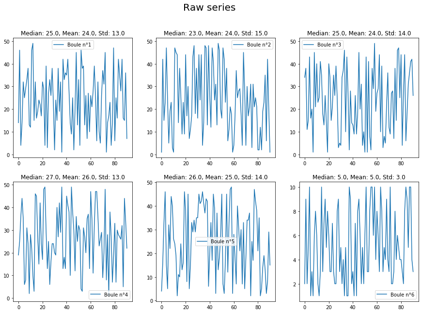

```python
f = plt.figure(figsize=(15,10))
for i in range(len(dic)):
    ax = f.add_subplot(plots[i])
    ax.plot(dic[i],label="Boule n°{}".format(i+1))
    median = round(np.median(dic[i]))
    mean = round(np.mean(dic[i]))
    std = round(np.std(dic[i]))
    ax.legend()

    ax.set_title("Median: {0}, Mean: {1}, Std: {2}".format(median,mean,std))
f.suptitle("Raw series",fontsize=20)
plt.show()
```

Each series appears to be well balanced.

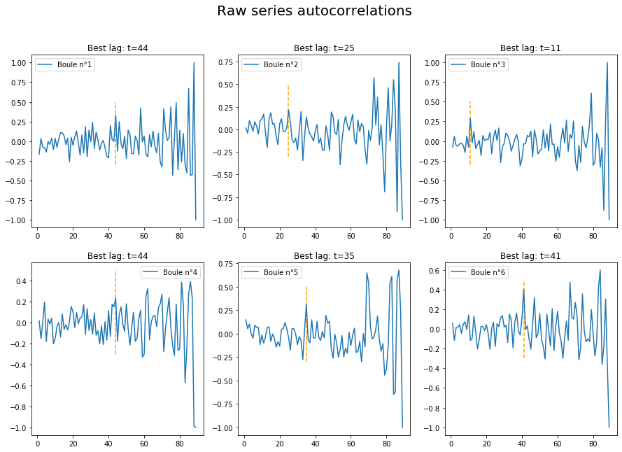

```python
def autocorr(x, t=1):
    return np.corrcoef(np.array([x[:-t], x[t:]]))

f = plt.figure(figsize=(15,10))
for i in range(len(dic)):
    ac = [(np.min(autocorr(dic[i],lag)[0]),lag) for lag in range(1,100)]
    ax = f.add_subplot(plots[i])
    ax.plot([lag[1] for lag in ac],[lag[0] for lag in ac],label="Boule n°{}".format(i+1))
    interesting = [lag[0] for lag in ac if lag[1]<50]
    best_lag = interesting.index(np.max(interesting))+1
    plt.vlines(x=best_lag, ymin=-0.3, ymax = 0.5,linestyle='dashed',color="orange")
    ax.legend()

    ax.set_title("Best lag: t={}".format(best_lag))
f.suptitle("Raw series autocorrelations",fontsize=20)
plt.show()
```

For each series, we look for the best partial autocorrelation (lag t < 50%). The results suggest the existance of repeated patterns for "boule 2" and "boule 3". It's intersting to know that since redondant information are "good features" for an LSTM model.

Robust lags are resistant to log transformation. Let's apply it:

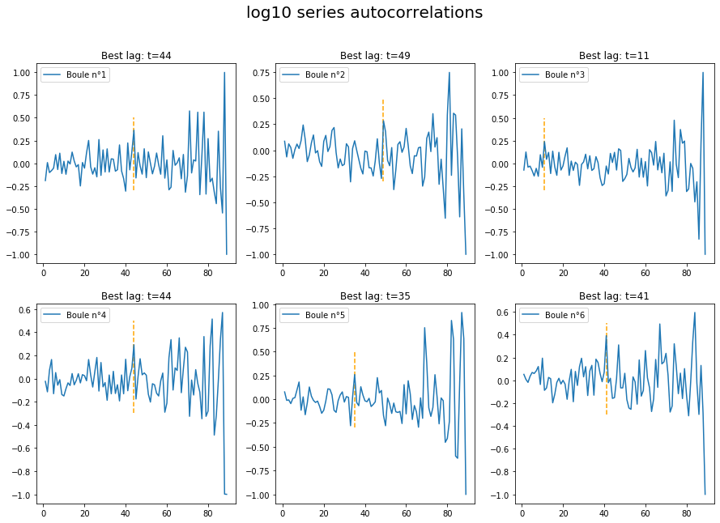

```python
f = plt.figure(figsize=(15,10))
for i in range(len(dic)):
    ac = [(np.min(autocorr(np.log(dic[i]),lag)[0]),lag) for lag in range(1,100)]
    ax = f.add_subplot(plots[i])
    ax.plot([lag[1] for lag in ac],[lag[0] for lag in ac],label="Boule n°{}".format(i+1))
    interesting = [lag[0] for lag in ac if lag[1]<50]
    best_lag = interesting.index(np.max(interesting))+1
    plt.vlines(x=best_lag, ymin=-0.3, ymax = 0.5,linestyle='dashed',color="orange")
    ax.legend()
    ax.set_title("Best lag: t={}".format(best_lag))
f.suptitle("log10 series autocorrelations",fontsize=20)
plt.show()
```

The "boule 2" best lag has increased indicating that the time serie is less autocorrelated.

We can consider another approach for the data by taking the drawset as a single flat time serie.

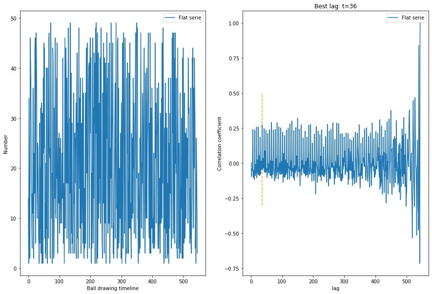

```python
flat = np.array(Tirages).flatten()
f = plt.figure(figsize=(15,10))
ax = f.add_subplot(121)
ax.plot(flat,label="Flat serie")
ax.set_xlabel("Ball drawing timeline")
ax.set_ylabel("Number")
ax.legend()
ax1 = f.add_subplot(122)
ac = [(np.min(autocorr(flat,lag)[0]),lag) for lag in range(1,len(flat))]
ax1.plot([lag[1] for lag in ac],[lag[0] for lag in ac],label="Flat serie")
interesting = [lag[0] for lag in ac if lag[1]<50]
best_lag = interesting.index(np.max(interesting))+1
plt.vlines(x=best_lag, ymin=-0.3, ymax = 0.5,linestyle='dashed',color="orange")
ax1.legend()
ax1.set_xlabel("lag")
ax1.set_ylabel("Correlation coefficient")
ax1.set_title("Best lag: t={}".format(best_lag))
plt.show()
```

Above results indicates a stable partial autocorrelation of the time series (correlation coefficient = 25 %). We choose the use this data to instanciate the LSTM model.

## Time serie processing

Here, we will apply a simple moving average:

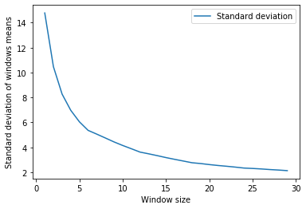

```python
def moving_average(list,size):
    return [np.mean(list[i:i+size]) for i in range(len(list)-size)]

stds_wins = [(np.std(moving_average(flat,size)),size)
             for size in range(30)]

plt.plot([i[1] for i in stds_wins],[i[0] for i in stds_wins],
         label="Standard deviation")
#plt.hlines(y=850,xmin=3,xmax=7,linestyle="--")
#plt.vlines(x=5,ymin=700,ymax=1000,linestyle="--")
plt.xlabel('Window size')
plt.ylabel("Standard deviation of windows means")
plt.legend()
plt.show()
```

We look for the elbow to select the window size. Here, 8 appears to be a good choice.

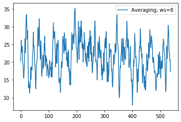

```python
flat_av = moving_average(flat,8)
plt.plot(flat_av,label="Averaging, ws=8")
plt.legend()
plt.show()
```

The data appears to be really stationary. That's good for the model since there are no outliers. However, the data is also uniformly distributed and it may prevent the model to learn robust features.

To take account of this, we will trend up the data by multipling the values by their ranks.

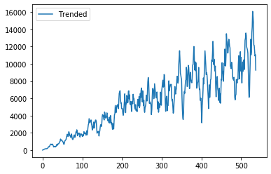

```python
flat_av_tr = [flat_av[i]*i for i in range(len(flat_av))]
plt.plot(flat_av_tr,label="Trended")
plt.legend()
plt.show()
```

## Model initialization

The data are trended and look great, let's build the model:

```python
X = [[i] for i in flat_av_tr]
```

```python
split = int(0.90*len(X))
```

```python
X_train = X[0:split]
X_test = X[split:]
```

```python
## Scale the data
scaler = MinMaxScaler(feature_range = (0, 1))
scaled = scaler.fit_transform(X_train)
scaled_test = scaler.fit_transform(X_test)
```

```python
## We define a window size (conventionnal ratio is 5%)
ws = round(0.05*len(X_train))
```

```python
## Then convert the training to the right format
features_set = np.array([scaled[i-ws:i,0] for i in range(ws,len(X_train))])
labels = np.array([scaled[i,0] for i in range(ws,len(X_train))])
features_set = np.reshape(features_set, (features_set.shape[0], features_set.shape[1], 1))
```

```python
test_features = np.array([scaled_test[i-ws:i,0] for i in range(ws,len(X_test))])
test_features = np.reshape(test_features, (test_features.shape[0], test_features.shape[1], 1))
```

```python
model = Sequential()

model.add(LSTM(units=30,return_sequences=True, input_shape=(features_set.shape[1], 1)))
model.add(Dropout(0.1))
model.add(LSTM(units=10))
model.add(Dense(units = 1))

model.compile(optimizer='adam',  # Optimizer
              # Loss function to minimize
              loss="mean_absolute_error",
              # List of metrics to monitor
              metrics=["mean_squared_error"])
```

```python
history = model.fit(features_set, labels, epochs =150, batch_size = 100)
```

```python
# Make predictions
predictions = model.predict(test_features)

# Unscale the predictions
predictions = scaler.inverse_transform(predictions)
```

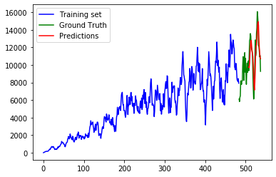

```python
plt.plot(X_train,label="Training set",color="blue")
plt.plot(range(len(X_train),len(X_train)+len(X_test)),X_test, label="Ground Truth",color="green")
plt.plot(range(len(X_train)+ws,len(X_train)+len(predictions)+ws),
         [i for i in predictions],
         label="Predictions",color="red")
#plt.xlim(480,530)
#plt.ylim(0,0.1)
plt.legend()
plt.show()
```

```python
### find the next values
for i in range(20):
    X_test.append(predictions[-1])
    scaled_test = scaler.fit_transform(X_test)
    test_features = np.array([scaled_test[i-ws:i,0] for i in range(ws,len(X_test))])
    test_features = np.reshape(test_features, (test_features.shape[0], test_features.shape[1], 1))
    # Make predictions
    predictions = model.predict(test_features)
    # Unscale the predictions
    predictions = scaler.inverse_transform(predictions)
```

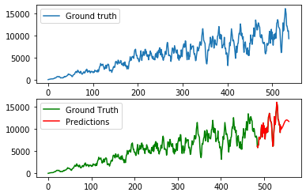

```python
plt.subplot(212)
plt.plot(X, label="Ground Truth",color="green")
plt.plot(range(len(X_train),len(X_train)+len(X_test)),
         X_test,
         label="Predictions",color="red")
#plt.xlim(480,530)
#plt.ylim(0,0.1)
plt.legend()
plt.subplot(211)
plt.plot(X,label="Ground truth")
plt.legend()
plt.show()
```

The model is well performing when it comes to validation. We are also able to predict new values in the short term.

Thanks for having read my work !